# ED Visit Demographic 2017

Below is data exploration exercise of Overlake Emergency Department Visit for 2017. Data set used is from Epic Caboodle Data Warehouse. We are looking at several dimensions of the data such as gender, race, insurance class, discharge type and arrival method.

### Data Set from Epic DW

```r
edVist <- sqlQuery(dataConn,"select edp.ArrivalMethod, edp.EdDisposition, edp.DischargeDisposition,edp.AcuityLevel,
  edp.FinancialClass, pt.name,pt.Sex, pt.PreferredLanguage, pt.FirstRace, pt.City , pt.PrimaryFinancialClass,
  MONTH(arrivalinstant) monthadm, year(getdate()) - year(birthdate) Age
  from EdVisitFact ed
  join EdVisitProfileDim edp on ed.EdVisitProfileKey = edp.Edvisitprofilekey
  join PatientDim pt on ed.PatientKey=pt.PatientKey
  where year(ArrivalInstant)=2017")
```

### Sample Data

```r
head(edVist, n=10)
```

| ArrivalMethod | EdDisposition | DischargeDisposition | AcuityLevel | FinancialClass | name | Sex | PreferredLanguage | FirstRace | City | PrimaryFinancialClass | monthadm | Age |
| --- | --- | --- | --- | --- | --- | --- | --- | --- | --- | --- | --- | --- |
| Tri-Med | Transfer to Another Facility | Psychiatric Hospital | Emergent | Aetna | HEFFERNAN,RYAN J | Male | English | White or Caucasian | SEATTLE | Aetna | 1 | 21 |
| Ambulatory | Admit | Home or Self Care | Emergent | Medicare | FRARE,SANDRA M | Female | English | White or Caucasian | BELLEVUE | Medicare | 1 | 74 |
| Ambulatory | Discharge | Home or Self Care | Less Urgent | Regence | DASZCZYNSKI,SYLVIA A | Female | English | White or Caucasian | RENTON | Self-pay | 10 | 21 |
| Bellevue Aid Unit | Admit | Skilled Nursing Facility | Urgent | MGD Medicare | MERRIAM,DON P | Male | English | White or Caucasian | BELLEVUE | MGD Medicare | 11 | 83 |
| Car | Admit | Home-Health Care Svc | Urgent | Medicare | SCOVIL,MILDRED G | Female | English | White or Caucasian | ISSAQUAH | Medicare | 2 | 87 |
| Car | Discharge | Home or Self Care | Less Urgent | Regence | GUILBERT,JEREMY H | Male | English | White or Caucasian | RENTON | Regence | 3 | 25 |
| Car | Discharge | Home or Self Care | Urgent | Regence | OROZCO,SAMANTA | Female | English | Hispanic | KENT | Self-pay | 6 | 20 |
| Ambulatory | Discharge | Home or Self Care | Urgent | Self-pay | DREW,KATHRYN N | Female | English | White or Caucasian | BELLEVUE | Self-pay | 1 | 31 |
| Ambulatory | Discharge | Home or Self Care | Urgent | United Healthcare | SINGH,SHIVANI | Female | English | Asian | REDMOND | United Healthcare | 3 | 39 |
| Car | Discharge | Home or Self Care | Less Urgent | MGD Medicaid | VANAUSDAL,MISTY K | Female | English | White or Caucasian | KIRKLAND | MGD Medicaid | 5 | 36 |

### Relationship between Insurance and Race

```r
table(edVist$FinancialClass,edVist$FirstRace)
```

```
                     *Unknown American Indian or Alaska Native Asian
  *Unspecified              5                                0     0
  Aetna                     0                                2   354
  Commercial                0                                0   251
  First Choice              0                                1    86
  Group Health Plan         0                                2   149
  Health Exchange           0                                4   194
  Managed Commercial        0                                1   315
  Medicaid                  2                               27    58
  Medicare                  0                               10   733
  MGD Medicaid              6                               19   799
  MGD Medicare              0                               11   376
  Premera                   0                               14  1332
  Regence                   0                               13   756
  Self-pay                 74                                6   396
  Tricare ChampVa           1                                1    28
  United Healthcare         0                                2   332
  Wa State LNI              0                                0    62
  Worker's Comp             0                                0    48

                     Black or African American Declined Hispanic Multiracial
  *Unspecified                               0        0        0           0
  Aetna                                     67       23       95          62
  Commercial                                44       12       69          34
  First Choice                              16        4       34           6
  Group Health Plan                         55        8       49          27
  Health Exchange                           24        8       41          13
  Managed Commercial                        37       14       45          35
  Medicaid                                  49        4      223          42
  Medicare                                 320       39      137          39
  MGD Medicaid                             913       71     1225         365
  MGD Medicare                             147       27       85          23
  Premera                                  170       67      236         215
  Regence                                  185       52      183         128
  Self-pay                                 215       10      648          71
  Tricare ChampVa                           22        1       20          14
  United Healthcare                         63       14       48          46
  Wa State LNI                              35        8      226          13
  Worker's Comp                             23        3       19           5

```

[output cut: 24 more lines]

```
  First Choice                         4                167
  Group Health Plan                   49                914
  Health Exchange                     15                456
  Managed Commercial                  47                695
  Medicaid                            22                288
  Medicare                            68               8481
  MGD Medicaid                       192               3902
  MGD Medicare                        38               3756
  Premera                            193               3673
  Regence                            152               3675
  Self-pay                            98                889
  Tricare ChampVa                      8                240
  United Healthcare                   66               1223
  Wa State LNI                        31                439
  Worker's Comp                       11                217
```

## Observation:

Most of Asian's patient insurance is Premera. For Hispanic, MGD Medicaid is the most. For Caucasian, Medicare is the highest with almost same distribution for the next 4 groups (Premera, Regence, MGD Medicaid, MGD Medicare).

### Relationship between Insurance and Gender

```r
table(edVist$PrimaryFinancialClass,edVist$Sex)
```

```
                             Female Male Unknown
  Aetna                         894  759       0
  Commercial                    205  194       6
  First Choice                  196  178       0
  Group Health Plan             625  430       0
  Health Exchange               394  301       0
  King County Project Access      1    0       0
  Managed Commercial            540  492       0
  Medicaid                      397  284       0
  Medicare                     5428 3774       0
  MGD Medicaid                 3781 3278       0
  MGD Medicare                 2325 1743       0
  Premera                      3068 2676       4
  Regence                      2497 2231       0
  Self-pay                     3365 3837       0
  Tricare ChampVa               151  166       0
  United Healthcare             853  815       0
```

```r
library(ggplot2)
```

### Number of ED Visit by Insurance Type

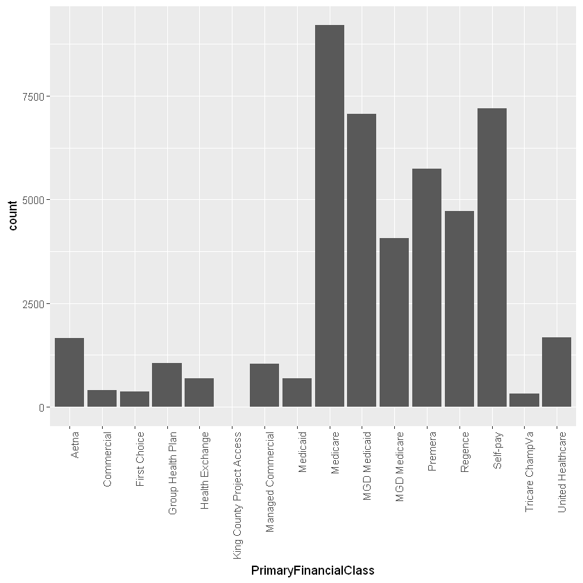

```r
require(ggplot2)
ggplot(edVist,aes(PrimaryFinancialClass))+
geom_bar()+theme(axis.text.x = element_text(angle = 90, hjust=1))
```

## Observation:

Private Insurance did not make it to top 3 groups of our ED Visit.

### Number of ED Visit by Race

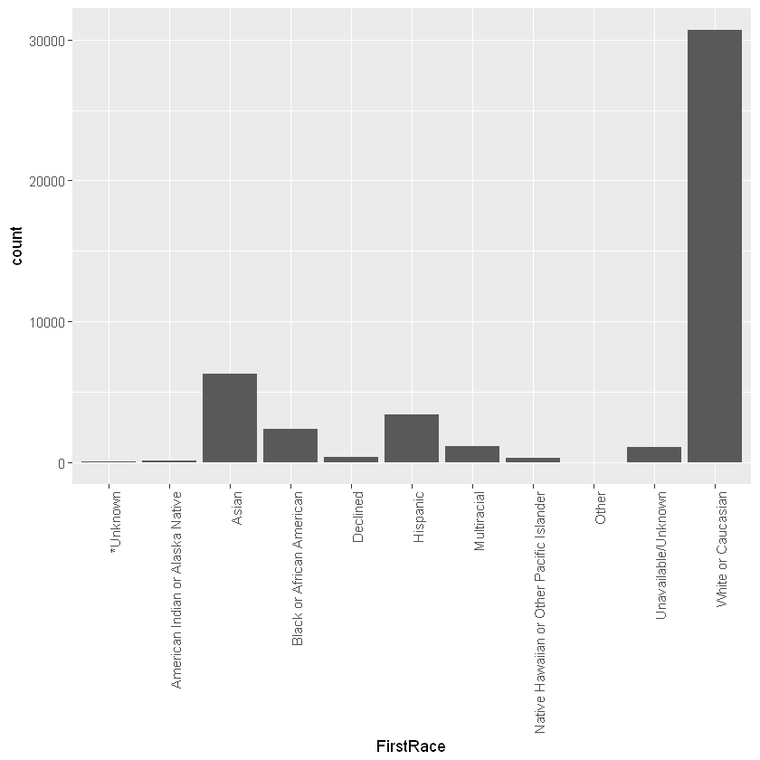

```r
ggplot(edVist,aes(FirstRace))+
geom_bar()+theme(axis.text.x = element_text(angle = 90, hjust=1))
```

## Number of ED Visit by Arrival Method

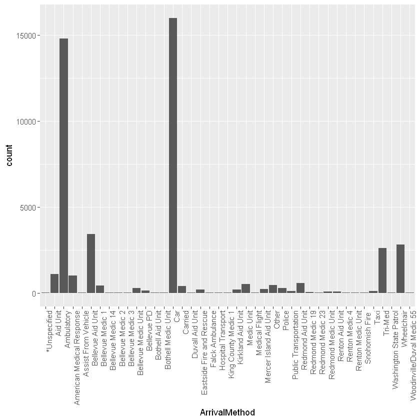

```r
ggplot(edVist,aes(ArrivalMethod))+
geom_bar()+theme(axis.text.x = element_text(angle = 90, hjust=1))
```

## Number of ED Visit by Discharge Type

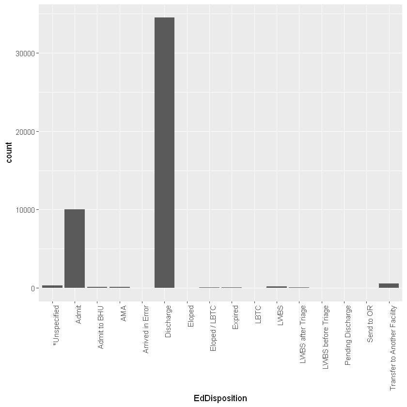

```r
ggplot(edVist,aes(EdDisposition))+
geom_bar()+theme(axis.text.x = element_text(angle = 90, hjust=1))
```

## Number of ED Visit by Discharge Destination

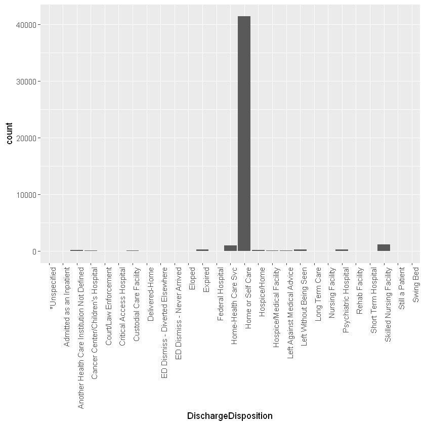

```r
ggplot(edVist,aes(DischargeDisposition))+
geom_bar()+theme(axis.text.x = element_text(angle = 90, hjust=1))
```

## ED Visit by Age

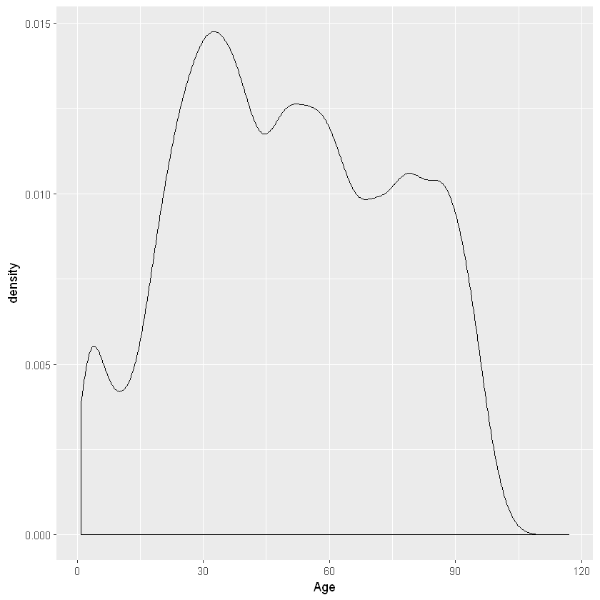

```r
ggplot(edVist,aes(Age))+geom_density()
```

## Observations:

Highest concentration of ED Visits is for patient ages 30-45

## ED Visit by Month

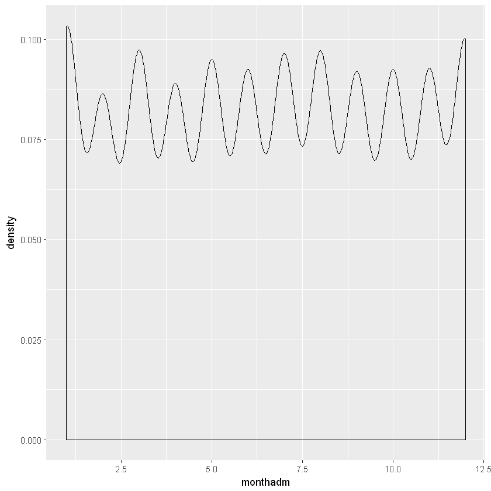

```r
ggplot(edVist,aes(monthadm))+geom_density()
```

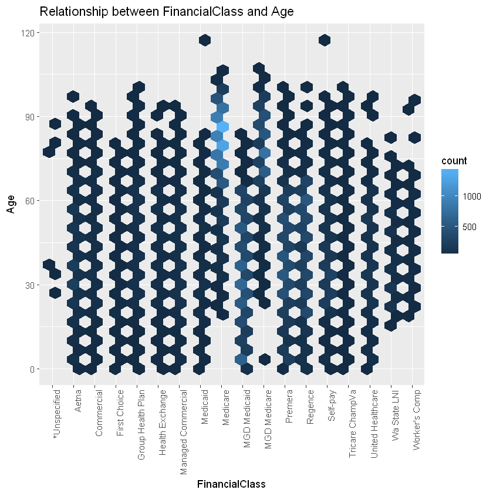

```r
ggplot(edVist,aes(FinancialClass,Age))+
stat_binhex(bins=30)+
xlab('FinancialClass')+ylab('Age')+
ggtitle('Relationship between FinancialClass and Age')+
theme(axis.text.x = element_text(angle = 90, hjust=1))
```

## Observations:

Highest concetration of ED patients is Medicare patient with age 75-90.

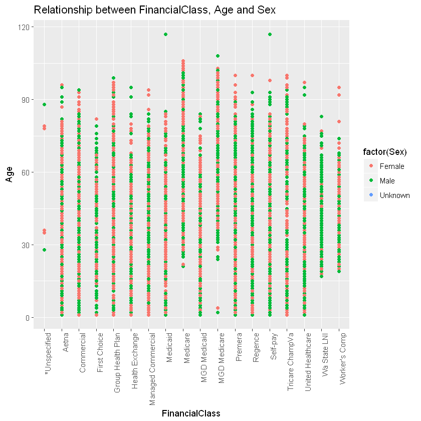

```r
ggplot(edVist,aes(FinancialClass,Age))+
geom_point(aes(color=factor(Sex)))+
xlab('FinancialClass')+ylab('Age')+
ggtitle('Relationship between FinancialClass, Age and Sex')+
theme(axis.text.x = element_text(angle = 90, hjust=1))
```

## Observations:

Highest concetration of ED patients is Medicare patient with age 75-90 and female.